# india_imr_1

Advait Rajagopal

June 25, 2017

## Data loading and munging

```r
#Loading packages and specs
library (dplyr)
library (rstan)
rstan_options(auto_write = TRUE)
options(mc.cores = parallel::detectCores())
library(broom)
```

```r
#Read in data
setwd("/Users/Advait/Desktop/New_School/Fall16/BDA/Finalproject/Infant_Mortality_India")
df <- read.csv("Julian_Final_Form.csv",
               header = TRUE,
               skip = 2)
str(df)
```

```
## 'data.frame':    315 obs. of  7 variables:
##  $ Year      : int  2003 2003 2003 2003 2003 2003 2003 2003 2003 2003 ...
##  $ State     : Factor w/ 35 levels "Andaman & Nicobar Islands",..: 1 2 3 4 5 6 7 8 9 10 ...
##  $ Male      : int  12 59 31 69 59 21 68 69 43 28 ...
##  $ Female    : int  24 59 38 65 62 16 71 39 34 29 ...
##  $ Person    : int  18 59 34 67 60 19 70 54 39 28 ...
##  $ Health.Exp: num  NA NA NA NA NA NA NA NA NA NA ...
##  $ Units     : Factor w/ 3 levels "","Lakh","R million": 1 1 1 1 1 1 1 1 1 1 ...
```

```r
#Drop Andaman and Nicobar & Dadra NH & Daman and Diu & Lakshadweep & Chandigarh and 2003
df <- df[df$Year != 2003,]
df <- df[df$State != "Andaman & Nicobar Islands"
         & df$State != "Dadra & Nagar Haveli"
         & df$State != "Daman & Diu"
         & df$State != "Lakshadweep"
         & df$State != "Chandigarh",]

#Fix names of Orissa, Jammu Kashmir and Chattisgarh
df$State <- as.character ( df$State )
df$State[ df$State == " Odisha "] <- " Orissa "
df$State [ df$State == " Jammu  &  Kashmir "] <- " Jammu  and  Kashmir "
df$State [ df$State == " Chhatisgarh "] <- " Chhattisgarh "
```

```r
#read in population data
#list.files()
pop <- read.csv("population.csv",
                header = T)

#attaching population to the data frame
ind <- merge(df,pop)
str(ind)
```

```
## 'data.frame':    240 obs. of  8 variables:
##  $ State     : chr  "Andhra Pradesh" "Andhra Pradesh" "Andhra Pradesh" "Andhra Pradesh" ...
##  $ Year      : int  2005 2009 2008 2007 2006 2010 2012 2011 2009 2011 ...
##  $ Male      : int  56 48 51 60 55 44 40 40 31 33 ...
##  $ Female    : int  58 50 54 37 58 47 43 46 34 31 ...
##  $ Person    : int  57 49 52 54 56 46 41 43 32 32 ...
##  $ Health.Exp: num  127787 28005 238613 204240 149447 ...
##  $ Units     : Factor w/ 3 levels "","Lakh","R million": 2 3 2 2 2 3 3 3 3 3 ...
##  $ X2011pop  : int  84580777 84580777 84580777 84580777 84580777 84580777 84580777 84580777 1383727 1383727 ...
```

```r
# Function for projecting population up or down
pop.func <- function (year, pop2011){
  pop <- NULL
  pop <- ifelse ( year > 2011 ,
                  pop2011 *(1.0184^( year - 2011)) ,
                  ifelse ( year < 2011,
                           pop2011 *((1/1.0184)^(2011 - year )),
                           pop2011 ))
  return (pop)
}
#Add column of projected population numbers
ind$population <- pop.func ( ind$Year , ind$X2011pop )
# Remove old population numbersx
ind <- ind [,-8]

##
#Put all currency in Ruppee
ind$exp.rup <- NULL
for (i in 1: length (ind [ ,1])){
  ind$exp.rup[i] <- ifelse(ind$Units [i] == "Lakh",
                           ind$Health.Exp[i]*100000 ,
                           ind$Health.Exp[i]*1000000)
}

#
#Get spending per capita
ind$percap <- ind$exp.rup/ ind$population

# Create ratio of female to male IMR
ind$fm.imr <- ind$Female / ind$Male

# Regress IMR ratio on health exp
summary(lm(fm.imr ~ percap ,
            data = ind ))
```

```
##
## Call:
## lm(formula = fm.imr ~ percap, data = ind)
##
## Residuals:
##      Min       1Q   Median       3Q      Max
## -0.73762 -0.06774  0.02080  0.07338  1.15188
##
## Coefficients:
##              Estimate Std. Error t value Pr(>|t|)
## (Intercept) 9.821e-01  2.111e-02  46.523  < 2e-16 ***
## percap      1.617e-04  2.695e-05   5.999 7.31e-09 ***
## ---
## Signif. codes:  0 '***' 0.001 '**' 0.01 '*' 0.05 '.' 0.1 ' ' 1
##
## Residual standard error: 0.2205 on 238 degrees of freedom
## Multiple R-squared:  0.1314, Adjusted R-squared:  0.1277
## F-statistic: 35.99 on 1 and 238 DF,  p-value: 7.315e-09
```

```r
# Sort by year
ind <- ind[ order ( ind$Year ),]
# Create state id
ind <- within (ind , state.id <- match (State , unique ( State )))
# Create Year id
ind <- within (ind , year.id <- match (Year , unique ( Year )))
```

## Some exploratory plots

1. This plot compares IMR in 2005 and 2012 to get an idea of how IMR has moved in the specified time span. It is clear that except for Mizoram, the IMR in 2012 is less than or equal to the IMR in 2005 for all other states.

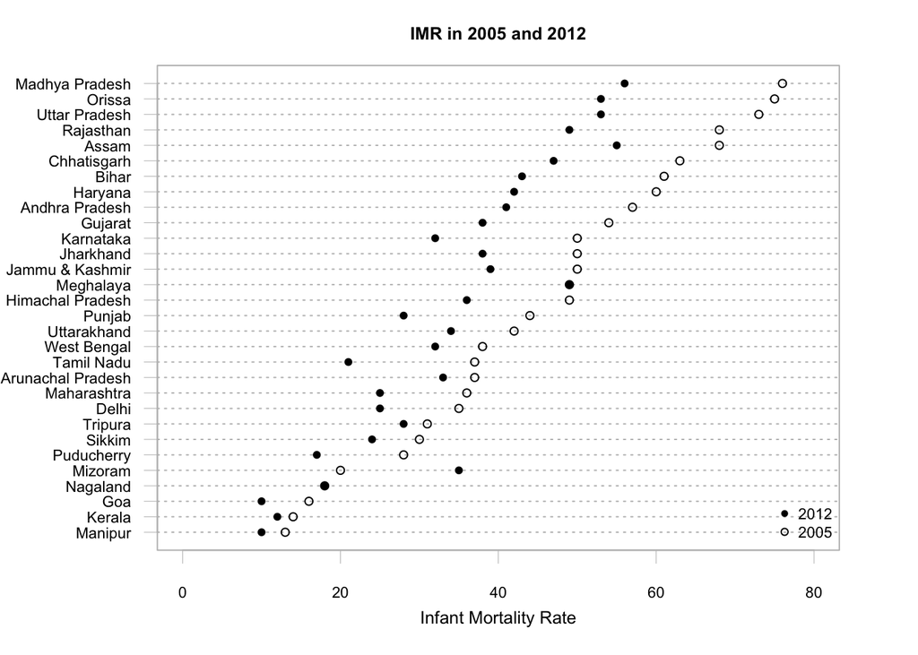

2. This plot shows the trend in IMR in the 30 Indian states under consideration for the specified time period 2005 - 2012.

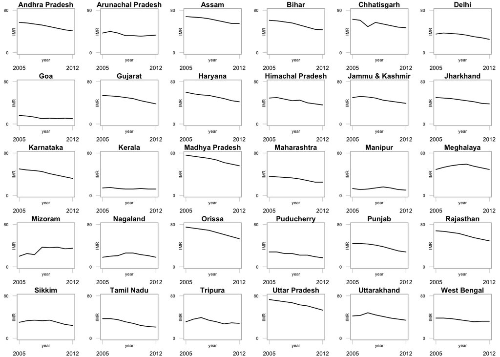

3. This plot shows the variation in IMR for males and females by state in the specified time period. The year 2007 is where a sharp drop in female IMR is observed. In red the values of female IMR in 2006, 2007 and 2008 are shown to reflect the sharp drop and subsequent rise in female IMR.

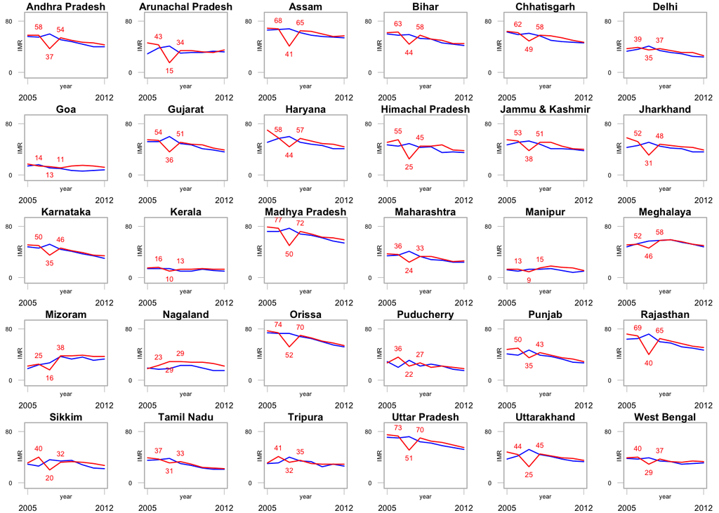

4. This plot is the ratio of female to male IMR. The dotted line is at one. If the line is above the dotted line, more female infants die and if the line is below the dotted line more males die with respect to females.

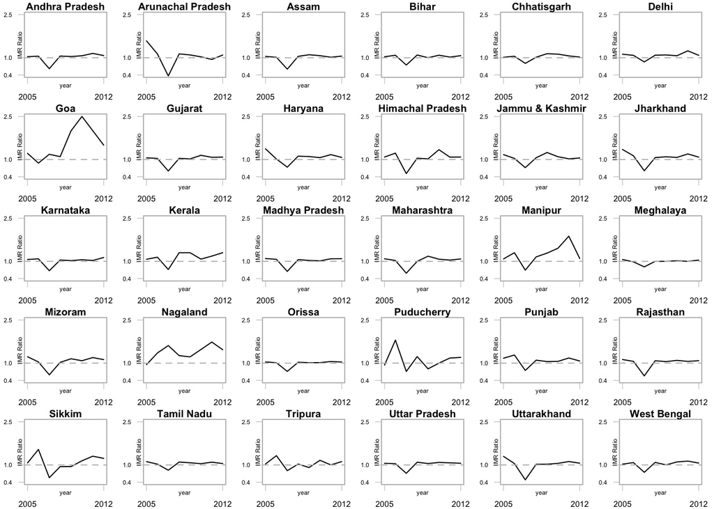

## Modeling

I model IMR as a function of percapita health expenditure using hierarchical Bayesian regression. I use health expenditure lagged by one period. I have a state level intercept, a time intercept and state level coefficients for the impact of health expenditure on IMR.

```r
#Some data munging to get the data ready for Stan. Also creating lags here.

###Re order by state id for lags to work
#creating "ind_temp" so as to not mess with the original data frame "ind"
ind_temp <- ind[order(ind$state.id),]
ind_temp <- ind_temp %>%
  group_by(State) %>%
  mutate(lag.exp = lag(percap, order_by = State))
#check if it works
# cbind(ind_temp$State,
#       ind_temp$Year,
#       ind_temp$year.id,
#       ind_temp$percap,
#       ind_temp$lag.exp)
#turns out it does, now add ind_temp$lag.exp to ind
ind <- ind[order(ind$state.id),]
ind$lag.exp <- ind_temp$lag.exp
# ind
#Drop NA in Year 2005
ind <- ind[complete.cases(ind),]
str(ind)
```

```
## 'data.frame':    210 obs. of  14 variables:
##  $ State     : chr  "Andhra Pradesh" "Andhra Pradesh" "Andhra Pradesh" "Andhra Pradesh" ...
##  $ Year      : int  2006 2007 2008 2009 2010 2011 2012 2006 2007 2008 ...
##  $ Male      : int  55 60 51 48 44 40 40 38 41 30 ...
##  $ Female    : int  58 37 54 50 47 46 43 43 15 34 ...
##  $ Person    : int  56 54 52 49 46 43 41 40 37 32 ...
##  $ Health.Exp: num  149447 204240 238613 28005 34492 ...
##  $ Units     : Factor w/ 3 levels "","Lakh","R million": 2 2 2 3 3 3 3 2 2 2 ...
##  $ population: num  77211096 78631780 80078605 81552051 83052609 ...
##  $ exp.rup   : num  1.49e+10 2.04e+10 2.39e+10 2.80e+10 3.45e+10 ...
##  $ percap    : num  194 260 298 343 415 ...
##  $ fm.imr    : num  1.055 0.617 1.059 1.042 1.068 ...
##  $ state.id  : int  1 1 1 1 1 1 1 2 2 2 ...
##  $ year.id   : int  2 3 4 5 6 7 8 2 3 4 ...
##  $ lag.exp   : num  169 194 260 298 343 ...
```

```r
###Preparing variables for Stan Model
#years start at 2006 so re-code year.id
year_id <- ind$year.id - 1
state_id <- ind$state.id
# imr <- ind$Person
imr_ratio <- ind$fm.imr
percap_exp <- ind$lag.exp
N <- length(ind$Person)
```

# Model 1 - The Normal Model

log(IMR(it)) ~ N(alpha_s(i) + alpha_t(t) + beta_exp(i) * log(percapita_exp(it)), sigma^2)

```r
#Model 1
#running Model 1 ----
#first run model_1 for females and save results
imr <- ind$Female
stanc("model_1.stan")
fit_1_f <- stan("model_1.stan",
              data = list("N",
                          "year_id",
                          "state_id",
                          "imr",
                          "percap_exp"),
              iter = 2000,
              chains = 4)
#second run model_1 for males and save results
imr <- ind$Male
stanc("model_1.stan")
fit_1_m <- stan("model_1.stan",
                data = list("N",
                            "year_id",
                            "state_id",
                            "imr",
                            "percap_exp"),
                iter = 2000,
                chains = 4)

#Preparing plots for Model 1
#extracting the results into dataframes
tidy_1_f <- tidy(fit_1_f, conf.int = T, conf.level = 0.50)
tidy_1_m <- tidy(fit_1_m, conf.int = T, conf.level = 0.50)
#
female_pred_1 <- tidy_1_f[75:284,2]
female_low_1 <- tidy_1_f[75:284,4]
female_hi_1 <- tidy_1_f[75:284,5]
#
male_pred_1 <- tidy_1_m[75:284,2]
male_low_1 <- tidy_1_m[75:284,4]
male_hi_1 <- tidy_1_m[75:284,5]
```

Viewing the results of the modeling.

1. The state intercepts

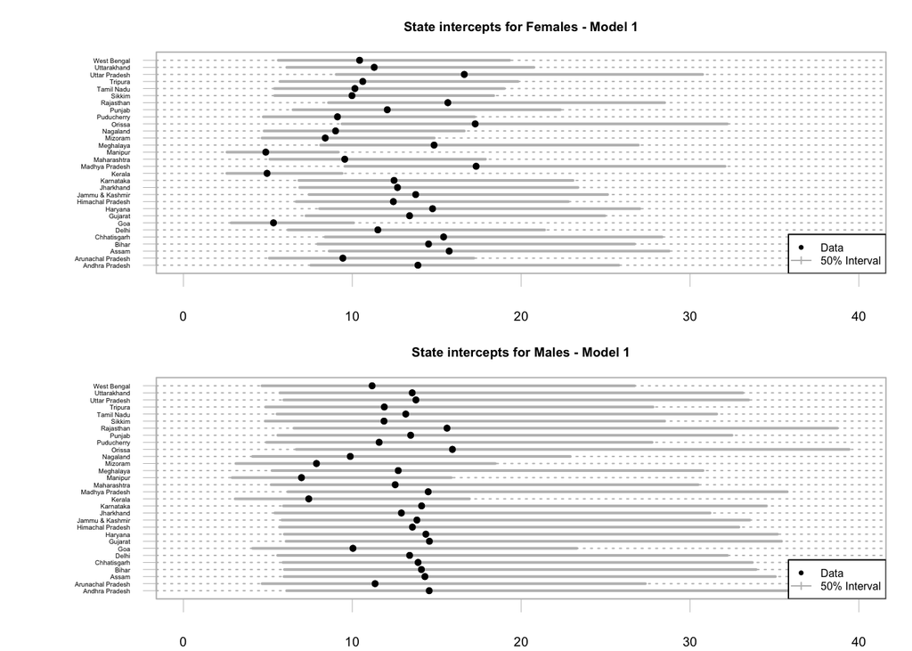

2. The time intercepts

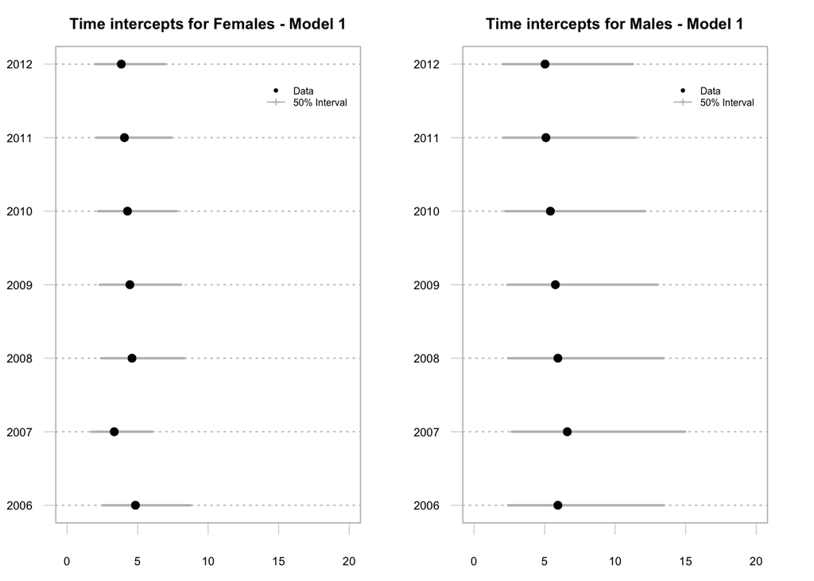

3. The marginal posterior of the beta or slope coefficient.

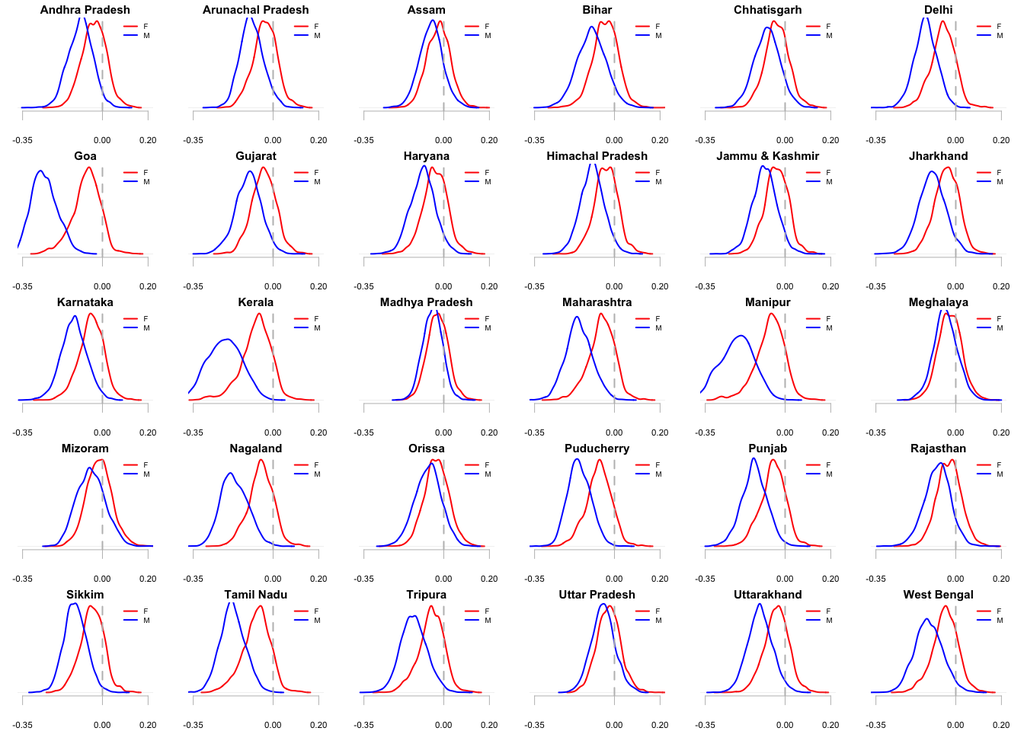

Model 1 - Posterior Predictive Checking for Females and Males.

The horizontal axes show the predicted values and the vertical axes show the original or true vales. The values cluster around the 45 degree line showing that the predictions are pretty good. The gray lines around the points show the 50% interval.

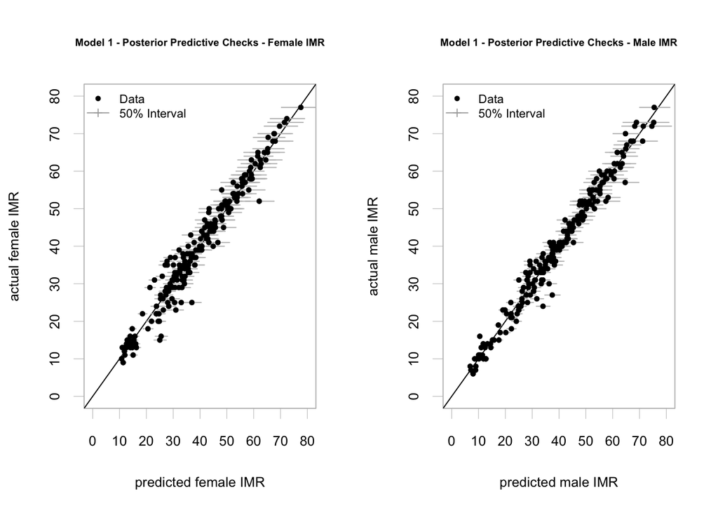

Posterior predictive checks in a grid for model 1. The following two plots show the performance of the model alongside the true data. The data is in black. The gray solid lines represent the prediction and the gray dashed lines represent the 50% posterior intervals.

1. Females

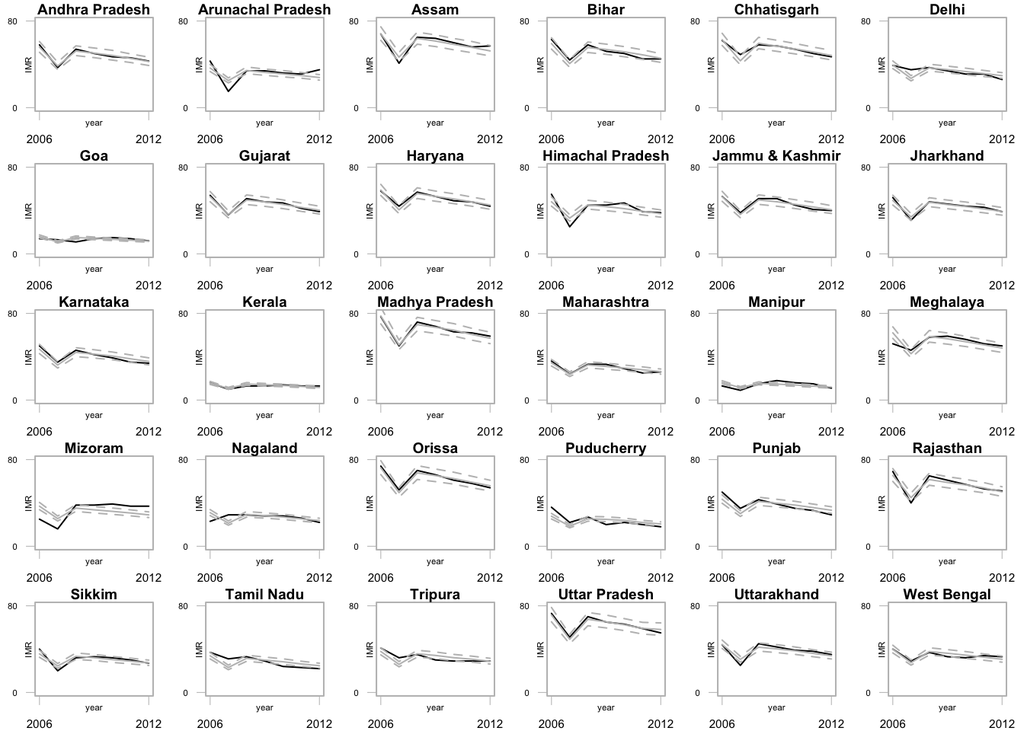

2. Males

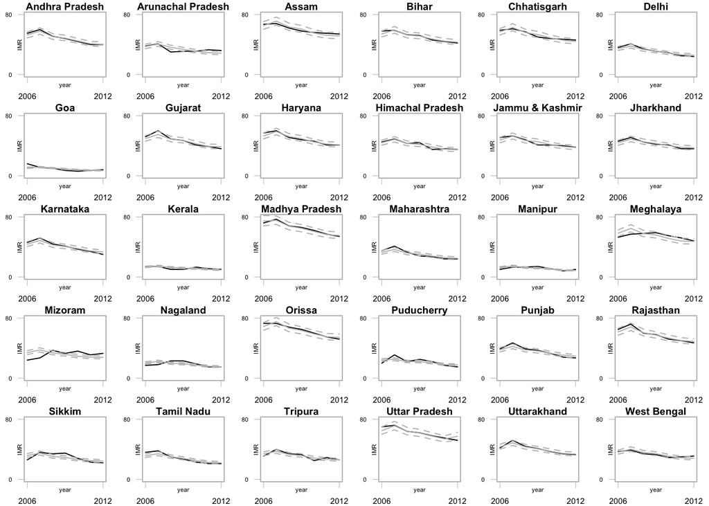